# Neural Network MARS Applicated on simulated data

## Accuracies

- Per iteration

```python
res_iter_reweighted
```

|  | acc_train | acc1_train | acc2_train | auc_train | acc_test | acc1_test | acc2_test | auc_test |
| --- | --- | --- | --- | --- | --- | --- | --- | --- |
| 0 | 0.729429 | 0.688790 | 0.827017 | 0.837458 | 0.721333 | 0.681733 | 0.817352 | 0.824173 |
| 1 | 0.719143 | 0.665597 | 0.851889 | 0.833399 | 0.727333 | 0.668912 | 0.859002 | 0.841035 |
| 2 | 0.724286 | 0.676271 | 0.844156 | 0.836666 | 0.726667 | 0.672147 | 0.847639 | 0.832622 |
| 3 | 0.720286 | 0.673304 | 0.831569 | 0.829875 | 0.736000 | 0.692164 | 0.845794 | 0.844277 |
| 4 | 0.726286 | 0.684853 | 0.823755 | 0.832423 | 0.726667 | 0.688951 | 0.822695 | 0.837246 |

- Mean

```python
res_mean_reweighted
```

```
acc_train     0.723886
acc1_train    0.677763
acc2_train    0.835677
auc_train     0.833964
acc_test      0.727600
acc1_test     0.680781
acc2_test     0.838497
auc_test      0.835871
dtype: float64
```

- std

```python
res_std_reweighted
```

```
acc_train     0.004246
acc1_train    0.009246
acc2_train    0.011924
auc_train     0.003119
acc_test      0.005283
acc1_test     0.010157
acc2_test     0.017707
auc_test      0.007852
dtype: float64
```

## Plot estimated splines

We here plot the estimated splines by NN-MARS. To do so, we generate a sequence of data and apply the best estimated NN-MARS (the one who maximises the AUC on the test sample).

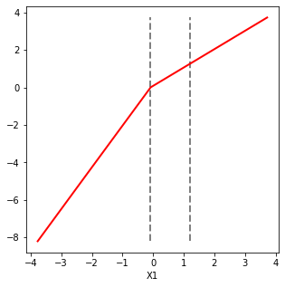

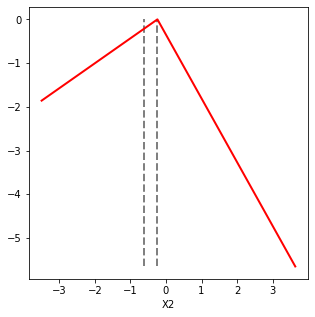

```python
NNMARS_plot_splines(X, models_fold_reweighted[np.argmax(res_iter['auc_test'])], figsize=(5,5), Save_Fig=False, path=[])
```

### Plot boundary

We here plot the estimated boundary on the training set. To do so, we plot the simulated data. Then we generate a meshgrid and apply the best estimated NN-MARS (the one who maximises the AUC on the test sample). We then add on the plot, the boundaries estimated by the first layer (in black) and the final decision rule (in red).

Remarks : this method works for binary classification problem with only 2 features.

This method was inspired by the work of Randall Balestriero concerning the vizualisation of splines estimated in deep networks provided here : https://github.com/RandallBalestriero/spline-DN-visualization

MIT License - Copyright (c) 2021 BALESTRIERO Randall

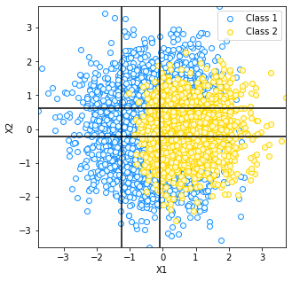

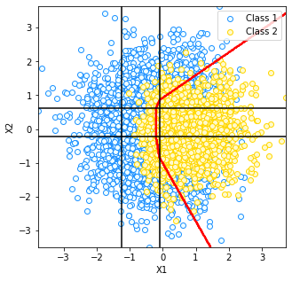

```python
outils_partition = Plot_partition_NN_MARS(data[['X1', 'X2']], np.array(data.label), models_fold_reweighted[np.argmax(res_iter_reweighted['auc_test'])])
meshgrid, Yhat_meshgrid = outils_partition.figure_partition()
```